# STA2060 - QUIZ 2

2024-02-05

# Library

```r
library(markovchain)
library(diagram)
```

# Questions

[figure not shown]

# Execution

## Question 1

```r
#enter the matrix
mat1 <- matrix(c(0, 3/4, 1/4, 0, 0, 1/2, 1/2, 0, 0, 0, 1/2, 1/2, 1, 0, 0, 0), byrow = TRUE, nrow = 4, ncol = 4)

#View the matrix
mat1
```

```
##      [,1] [,2] [,3] [,4]
## [1,]    0 0.75 0.25  0.0
## [2,]    0 0.50 0.50  0.0
## [3,]    0 0.00 0.50  0.5
## [4,]    1 0.00 0.00  0.0
```

For a better interpretation of the markov chain, I visualised the markov chain represented by the given matrix. For that used the `plotmat()` function from the `diagram` library, for which I need to get transpose of the matrix in order to use.

I obtain the transpose of mat1 as shown below:

```r
mat1_transpose <- t(mat1)
mat1_transpose
```

```
##      [,1] [,2] [,3] [,4]
## [1,] 0.00  0.0  0.0    1
## [2,] 0.75  0.5  0.0    0
## [3,] 0.25  0.5  0.5    0
## [4,] 0.00  0.0  0.5    0
```

I then visualised the markov chain as follows:

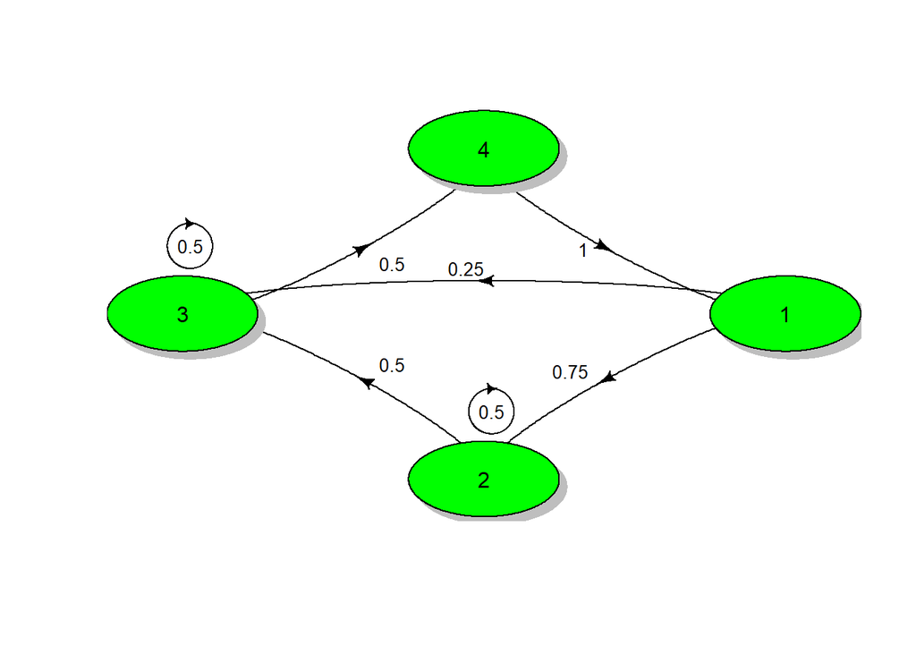

```r
plotmat(mat1_transpose, arr.length=0.3, arr.width=0.15, box.col="green", box.lwd=1, box.prop=0.5, box.size=0.1, box.type="circle", cex.txt=0.85, lwd=1, self.cex=0.3, self.shiftx=0.01, self.shifty=0.09)
```

I then set up a new markov chain object using the `new()` function.

In terms of Object Oriented Programming, I am instantiating a specific instance of a Markov Chain that I can manipulate and interact with in my code.

This is a requirement for using functions within the `markovchain` library, which I will be using in the next steps.

```r
#create a new markov chain object
mChain1 <- new("markovchain", states=c("1","2","3","4"), transitionMatrix=mat1)

mChain1
```

```
## Unnamed Markov chain
##  A  4 - dimensional discrete Markov Chain defined by the following states:
##  1, 2, 3, 4
##  The transition matrix  (by rows)  is defined as follows:
##   1    2    3   4
## 1 0 0.75 0.25 0.0
## 2 0 0.50 0.50 0.0
## 3 0 0.00 0.50 0.5
## 4 1 0.00 0.00 0.0
```

I then obtained the Steady State matrix of the given transition matrix.

> The **Steady State Matrix** of a transition matrix in a markov chain represents the long term distribution of probabilities for being in each state. Mathematically, it is given by $\pi P = \pi$ where:
> - $\pi$ is a row vector where each element represents the probability of being in a specific state in the long run
> - $P$ is the transition matrix that defines the probabilities of moving from one state to another.

I used the `steadyStates()` function from the `markovchain` library to get the steady state matrix.

```r
#get the steady state matrix
mat1ss<- steadyStates(mChain1)

#view the matrix
mat1ss
```

```
##              1         2         3         4
## [1,] 0.1818182 0.2727273 0.3636364 0.1818182
```

I then defined the cost matrix $\begin{bmatrix} 125 \\ 0 \\ 0 \\ 75 \\ \end{bmatrix}$ such that **$125** is associated with the overhauled class and **$75** is associated with the inoperative class.

```r
# cost matrix
costMatrix <- matrix(c(125, 0, 0, 75), byrow = TRUE, ncol = 1, nrow = 4)

#View the cost matrix
costMatrix
```

```
##      [,1]
## [1,]  125
## [2,]    0
## [3,]    0
## [4,]   75
```

In order to get the total expected per day costs of maintenance, we can multiply the steady state matrix ( $\pi$ ) by the cost matrix ( $C$ ), and the resultant $1 \times 1$ matrix will be the result. This can be represented in the formula:

$$\pi \times C = TotalExpectedCosts$$

I thus multiplied the steady state matrix by the cost matrix as shown below:

```r
#calculate the expected cost per state
expectedCost <- mat1ss %*% costMatrix

#View the vector
cat('The total expected per day cost of maintencance is', expectedCost)
```

```
## The total expected per day cost of maintencance is 36.36364
```

The total expected cost of maintenance per day is obtained as $36.36364$

## Question 2

### i) Develop a transition matrix for patients from the historical data described above.

The historical data on hope hospitals weekly ward transitions can be summarised as follows:

|  | Outpatient | Ward | ICU |
| --- | --- | --- | --- |
| **Outpatient** | 85% | 10% | 5% |
| **Ward** | not given | 50% | 10% |
| **ICU** | not given | 50% | 50% |

As per the rules of markov chains, each of the transition matrix’s row values must add up to a proportion of one. Thus the values for **Ward –> Outpatient** and **ICU –> Outpatient** can be found by obtaining the sum of the rows, and subtracting this sum from 100%, as follows:

```r
#Ward --> Outpatient
w <- 100 - (50 + 10)

#ICU --> Outpatient
i <- 100 - (50 + 50)

#print results
cat('Ward --> Outpatient:', w, '\n ICU --> Outpatient:', i )
```

```
## Ward --> Outpatient: 40
##  ICU --> Outpatient: 0
```

I then created the transition matrix given the historical data and these calculated values, in which O represents Outpatient, W represents Ward and I represents ICU.

```r
#define matrix of hope hospital historical data
mat2 <- matrix(c(85, 10, 5, 40, 50, 10, 0, 50, 50), byrow = TRUE, nrow = 3, ncol = 3,
               dimnames = list(c('O', 'W', 'I'), c('O', 'W', 'I')))

#View the matrix
mat2
```

```
##    O  W  I
## O 85 10  5
## W 40 50 10
## I  0 50 50
```

I then divided this matrix of percentages by 100, to obtain the elements as proportions ranging from 0 to 1.

```r
#divide matrix by 100
mat2 <- mat2/100
mat2
```

```
##      O   W    I
## O 0.85 0.1 0.05
## W 0.40 0.5 0.10
## I 0.00 0.5 0.50
```

Thus the transition matrix ( $T1$ ) for patients is

$$T1 = \begin{bmatrix}
& \text{O} & \text{W} & \text{I} \\\text{O} & 0.85 &
0.10 & 0.05 \\\text{W} & 0.40 & 0.50 & 0.10 \\\text{I}
& 0.00 & 0.5 & 0.50 \\\end{bmatrix}$$

I then visualised this transition matrix using the `plotmat()` function from the `diagram` library.

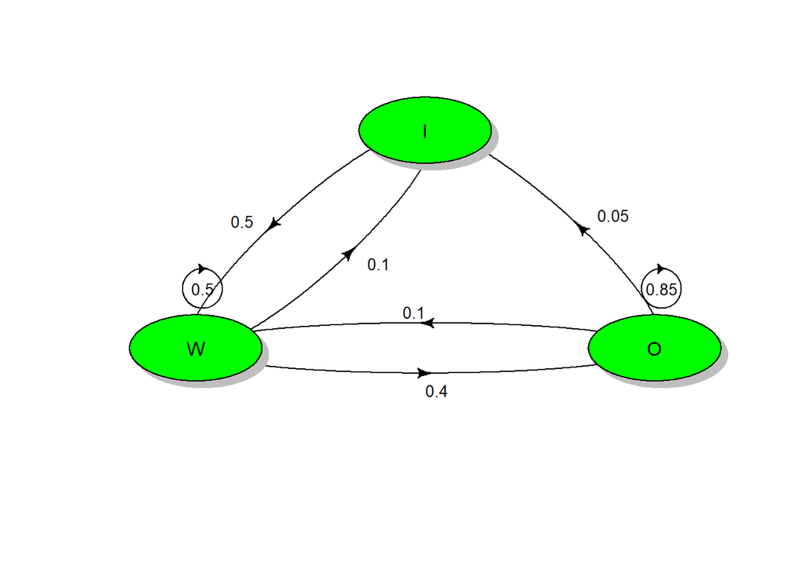

```r
#get the transpose of the matrix
mat2_transpose <- t(mat2)

#plot the markovchain
plotmat(mat2_transpose, arr.length=0.3, arr.width=0.15, box.col="green", box.lwd=1, box.prop=0.5, box.size=0.1, box.type="circle", cex.txt=0.85, lwd=1, self.cex=0.3, self.shiftx=0.01, self.shifty=0.09)
```